# Central tendency measures

note that in the R codes `x` is a vector of values. Vectors can be created with `c()` for examle:

```r
c(1,2,3,4,5,6)
```

```
[1] 1 2 3 4 5 6
```

### Mode

- A simple central tendency that can be used for all scale levels
- The mode indicates which expression occurs most frequently
- If the absolute (or relative) frequency distribution has a unique maximum, the mode is unique and is denoted by x(mod)
- In the bar chart, the mode is the expression with the highest column
- the mode does not always have to be unique
- calculation in R: `Mode <- function(x) { ux <- unique(x) ux[which.max(tabulate(match(x, ux)))] } mode <- Mode(x)`

##### Properties of the mode

- If only very few values of the list of observations match the mode is not very meaningful

### Arithmetic mean

- calculation in R: `mean(x)`
- for grouped data the arithmetic mean from the midpoints of the classes has to be calculated

##### Properties of the arithmetic mean

- the arithmetic mean is very sensitive to outliers
- This sensitivity to outliers can be undesirable (e.g. individual errors in the data lead to large changes in the arithmetic mean)

### Median

- for at least ordinally scaled characteristics
- One half of the values of the original list should be below the median and the other half above
- For odd 𝒏𝒏 the median is the middle value of the ordered data
- calculation in R: `median(x)`

#### Properties of the median

- robust against outliers
- At least 50% of the values in the data are less or equal to the median
- At least 50% of the values in the data are greater or equal to the median

### Quantiles

#### Properties of the Quantiles and the interquartile range

- robust against outliers
- do not contain any information about the left and right ends

### five point summary

- The five-point summary of the distribution of ametric variable consists of :  
  x(min), 0.25 - Quantile, median, 0.75 - Quantile, x(max)
- visualization in R: `boxplot(x)`
- example:

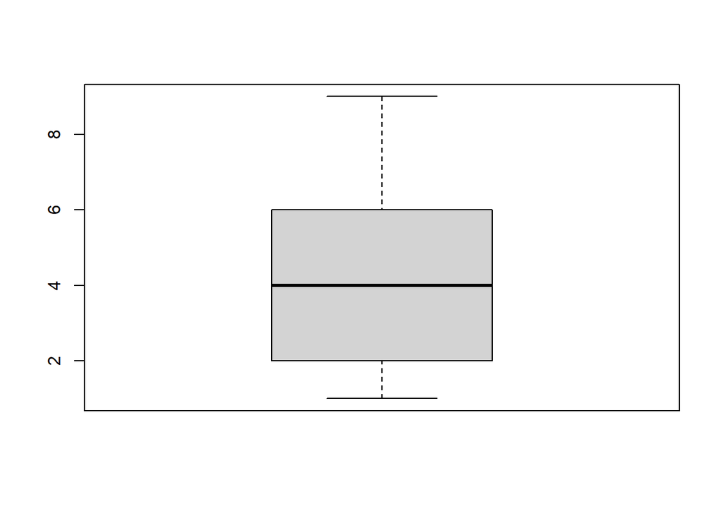

```r
x <- c(1,4,6,3,7,9,4,2,1,4)
boxplot(x)
```

#### Overview

|  |  | Mode | Arithmetic mean | Median | Quantiles |
| --- | --- | --- | --- | --- | --- |
| Applicable for different scale levels | nominal | yes | no | no | no |
|  | ordinal | yes | no | yes | yes |
|  | cardinal | yes | yes | yes | yes |
| Robust against outliers |  | yes | no | yes | yes |

### Storage Rules

[output not shown]

Back to Table of Contents